# Suivi de l’analyse

# Analyse Descriptive

## Données manquantes

**Variables mal renseignées:** Les variables *Antécédent de dyslipidémie du donneur* (40% de données manquantes), *Sérologie AcHBs du donneur* (33%) et *antécédents de grossesse* (36% chez les femmes) sont mal renseignées avec plus d’un tiers de données manquantes. Ces variables devraient être exclues des analyses.

**Autres données manquantes:** La plupart des autres variables présentent des proportions de données manquantes plus restreintes On pourra proposer, en analyse de sensibilité, d’évaluer l’effet de ces problèmes de reseignement sur le modèle. Aucune donnée manquante n’a été relevée sur les variables descriptives du suivi (évènement, temps d’évènement).

## Partition apprentissage/ validation

La partition aléatoire entre l’échantillon d’apprentissage et l’échantillon de validation semble avoir produit deux échantillons comparables en termes de distribution pour l’ensemble des variables de la base. De petits écarts de distribution semblent toutefois apparaître sur les indicatrices des immunisations anti-HLA.

## Variables quasi-séparées

Plusieurs variables catégorielles sont presque exclusivement unimodales, et ne pourraient donc être exclues des analyses faute d’apport d’information (et pouvant potentiellement entraver le calcul des modèles):

- Sérologies HCV, AgHBs, HIV donneur/receveur
- Traitements par inhibiteurs de mTOR et apparentés CNI
- Immunisation DSA
- Incompatibilité ABO (unimodale)

## Descriptif des données

Au sein de l’échantillon d’apprentissage (N=4844), la population des receveurs répond aux caractéristiques démographiques de l’insuffisance rénale chronique, avec une nette majorité masculine (64%) et deux tiers de la population âgée d’entre 39 et 67 ans, pour un âge moyen de 53.2 ans. 25.2% des receveurs présentent une étiologie récidivante d’IRC. Au global, une majorité des patients ont reçu un traitement par hemodialyse (78.5%) ou par dialyse péritonéale (10.6%). Seuls 10.7% bénéficient d’une greffe préemptive et ne sont pas passés par la dialyse, correspondant à la tendance nationale rapportée par le réseau REIN en 2019 (10.9%). 80.4% des receveurs présentent des antécédents d’hypertension, 39.4% des antécédents de maladies cardiovasculaires, un tiers (33.7%) des antécédents de dyslipidémie et 18.9% des antécédents de diabète. Les antécédents de néoplasie et de maladies urologiques présentent des prévalences plus faibles, autour de 10%.

Les temps passés sur liste d’attente et en dialyse sont très hétérogènes, témoignant de disparités géographiques et démographiques importantes en termes d’accès à la greffe. Cependant, ces durées restent globalement longues, avec une durée d’attente moyenne de 703 jours (près de 2 ans) et 1157 jours en dialyse (3 ans et 2 mois). De plus, 75% des receveurs ont attendu plus de 221 jours (plus de 7 mois) et 75% d’entre deux ont passé plus de 495 jours (1 an et 4 mois) en dialyse.

Les donneurs répondent à de caractéristiques similaires en termes d’âge (âge moyen de 53.1 ans) mais sont plus hétérogènes (écart-type de 17.2 ans contre 14.4 ans, du fait de la présence de donneurs mineurs, pédiatriques et de donneurs âgés) et également majoritairement masculins (59.7%). 8.3% des donneurs ont été prélevés à coeur arrêté et 49.1% ont subi un décès de cause cardiovasculaire. Les antécédents médicaux des donneurs correspondaient davantage aux propriétés de la population générale française, avec une prévalence des antécédents d’hypertension de 28.7% et une prévalence du diabète de 6.8%. La prévalence de la protéinurie sont nettement plus élevées que les estimations populationnelles (38.3%), ce qui était attendu pour des donneurs cadavériques. Au regard de leurs caractéristiques, 42.1% des donneurs sont considérés marginaux par le critère historique ECD.

D’un point de vue immunologique, 50% des couples donneur-receveur présentent entre 3 et 4 incompatibilités HLA ABDR et aucun ne présente d’incompatibilité de groupe sanguin. Concernant les immunisations des receveurs, 18.5% (classe I) et 15.4% (classe II) sont positifs à l’immunisation anti-HLA.

Les sérologies des donneurs et receveurs sont pour la plupart soit très majoritairement positives (EBV) ou très majoritairement négatives (HCV, AgHBs, HIV) et ont été exclues des analyses en conséquence.

Les variables relatives à la greffe correspondent aux attentes au vu des pratiques courantes en transplantation dans le pays. Ainsi, le temps d’ischémie froide était inférieur à 1 jour pour plus de 75% des partients (Q3=21) et une très forte majorité des patients ont reçu des traitements par antiprolifératifs et corticoïdes, ainsi qu’au tacrolimus à partir de 2009 (87.2%). Près d’un greffon sur trois (29.1%) a été placé sous machine de perfusion.

On note par ailleurs la présence d’un écart-type important par rapport à la moyenne sur la variable *urée du donneur*. Cette valeur s’explique par la présence d’outliers, 6 donneurs présentant des valeurs d’urée au-dessus de 200 mmol/L alors que la quasi-totalité des valeurs sont inférieures à 50 mmol/L.

|  | Missing (learning sample) | Learning sample (N=4844) | Missing (validation sample) | Validation sample (N=2778) |
| --- | --- | --- | --- | --- |
| **Quantitative characteristics - mean ± SD (Q1-Q3)** |  |  |  |  |
| Recipient age (years) | 0 | 53.2 ± 14.4 (43-64) | 0 | 53.8 ± 14.5 (44-65) |
| Recipient BMI kg/m² | 38 | 25.1 ± 4.6 (21.8-28) | 23 | 25.4 ± 4.6 (21.9-28.6) |
| Time on waiting list (days) | 145 | 703.4 ± 635.5 (221.5-1023.5) | 88 | 745.8 ± 649.2 (250-1062.2) |
| Time on dialysis (days) | 540 | 1157.2 ± 1014.1 (495-1526.2) | 317 | 1210.8 ± 1055.4 (546-1606) |
| CIT (hours) | 13 | 17.5 ± 7.3 (12.3-21) | 11 | 17.4 ± 7.3 (12.3-20.8) |
| Donor age (years) | 26 | 53.1 ± 17.2 (43-66) | 14 | 53.9 ± 17.1 (44-67) |
| Donor height (cm) | 575 | 169.1 ± 11.2 (163-176) | 295 | 169.3 ± 11.7 (163-177) |
| Donor weight (kg) | 574 | 73.7 ± 16.8 (63-83.5) | 295 | 73.8 ± 17.3 (62-84) |
| Last donor diuresis (mL) | 411 | 176.1 ± 202.3 (70-200) | 231 | 175 ± 190.2 (65-200) |
| Donor urea (mmol/L) | 198 | 6.9 ± 25.1 (3.6-7.4) | 115 | 6.5 ± 18.8 (3.6-7.3) |
| Donor creatinine (µmol/L) | 13 | 91.3 ± 60.1 (58-104) | 10 | 89.1 ± 56.6 (57-101) |
| HLA A-B-DR incompatibilities | 97 | 3.4 ± 1.2 (3-4) | 52 | 3.4 ± 1.2 (3-4) |
| **Categorical characteristics - N (%)** |  |  |  |  |
| Recipient men | 0 | 3112 (64.24) | 0 | 1712 (61.63) |
| Relapsing initial nephropathy | 0 | 1220 (25.19) | 0 | 689 (24.8) |
| Preemptive transplantation | 12 | 518 (10.69) | 11 | 308 (11.09) |
| Peritoneal dialysis | 12 | 514 (10.61) | 11 | 286 (10.3) |
| Hemodialysis | 12 | 3800 (78.45) | 11 | 2173 (78.22) |
| Post-transplant dialysis | 217 | 1267 (26.16) | 120 | 706 (25.41) |
| History of smoking | 0 | 1844 (38.07) | 0 | 961 (34.59) |
| History of diabetes | 0 | 914 (18.87) | 0 | 578 (20.81) |
| History of Dyslipidemia | 0 | 1633 (33.71) | 0 | 898 (32.33) |
| History of hypertension | 0 | 3895 (80.41) | 0 | 2234 (80.42) |
| History of cardiovascular disease | 0 | 1906 (39.35) | 0 | 1040 (37.44) |
| History of neoplasia | 0 | 534 (11.02) | 0 | 290 (10.44) |
| History of urological disease | 0 | 537 (11.09) | 0 | 302 (10.87) |
| Positive recipient CMV serology | 38 | 2863 (59.1) | 32 | 1713 (61.66) |
| Positive recipient AcHBs serology | 87 | 3126 (64.53) | 60 | 1765 (63.53) |
| Positive donor CMV serology | 8 | 2510 (51.82) | 15 | 1475 (53.1) |
| Donor men | 5 | 2891 (59.68) | 7 | 1644 (59.18) |
| Donor after cardiac death | 4 | 402 (8.3) | 7 | 239 (8.6) |
| Donor death vascular etiology | 0 | 2379 (49.11) | 0 | 1338 (48.16) |
| Donor history of hypertension | 335 | 1390 (28.7) | 169 | 852 (30.67) |
| Donor history of diabetes | 663 | 328 (6.77) | 348 | 225 (8.1) |
| Donor history of cardiac arrest | 75 | 1448 (29.89) | 60 | 839 (30.2) |
| Donor proteinuria positive | 451 | 1853 (38.25) | 226 | 1049 (37.76) |
| Depleting induction therapy | 20 | 2553 (52.7) | 25 | 1440 (51.84) |
| Pre-transplantation anti-HLA immunization of class I | 595 | 894 (18.46) | 396 | 673 (24.23) |
| Pre-transplantation anti-HLA immunization of class II | 888 | 746 (15.4) | 540 | 557 (20.05) |
| Transplanted before 2012 | 0 | 2249 (46.43) | 0 | 1141 (41.07) |

## Descriptif de la survie

### Kaplan-Meier global

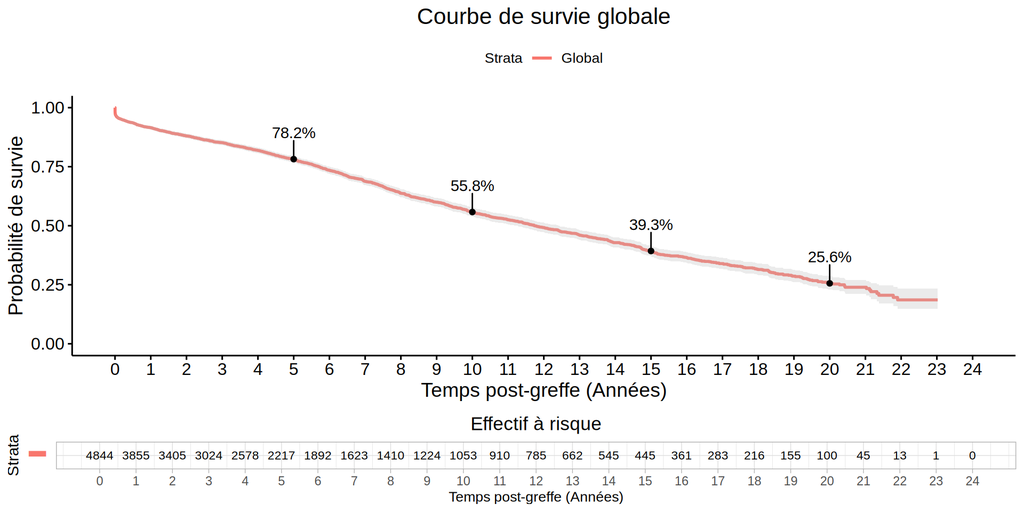

### Kaplan-Meier par centre

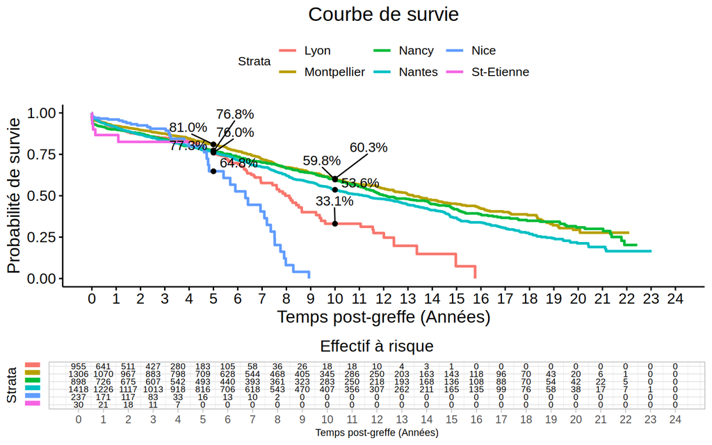

### Indicateurs descriptifs de la survie

#### Echantillon d’apprentissage

**Nombres d’évènements:** 977 retours en dialyse, 1010 décès dont 757 avec greffon fonctionnel, 3110 censures

**Personnes-années:** 28797 personnes-années

**Incidence en personne-année:** 0.03 retours en dialyse par personne-année, 0.04 décès par personne-année

**Follow-up médian:** 11.7 ans

**Probas de survie:**

- 5 ans: 78% [77%-79%]
- 10 ans: 56% [54%-58%]
- 15 ans: 39% [37%-42%]
- 20 ans: 26% [23%-29%]

#### Echantillon de validation

**Nombres d’évènements:** 510 retours en dialyse, 507 décès dont 375 avec greffon fonctionnel, 1893 censures

**Personnes-années:** 15079 personnes-années

**Incidence en personne-année:** 0.03 retours en dialyse par personne-année, 0.03 décès par personne-année

**Follow-up médian:** 12 ans

**Probas de survie:**

- 5 ans: 79% [77%-80%]
- 10 ans: 58% [56%-61%]
- 15 ans: 40% [37%-43%]
- 20 ans: 25% [21%-29%]

# Analyse univariée

## Liens entre variables du donneur et du receveur

Les liens potentiels entre les variables du donneur et du receveur ont été testés afin d’identifier des interactions candidates à la prise en compte dans le modèle et repérer des candidats au statut de facteur de confusion. Pour cette étape, le lien entre les variables quantitatives et entre les paires quantitatives-qualitatives a été évalué par des modèles de régression linéaire, et le lien entre les variables qualitatives a été évalué par des tests du $\chi2$.

##### Quanti-Quanti

|  | Donor age | Donor height | Donor weight | Last donor diuresis | Donor urea | Donor creatinine |
| --- | --- | --- | --- | --- | --- | --- |
| Recipient age | 0 | 0 | 0 | 0.009 | 0.009 | 0 |
| Recipient BMI | 0 | 0.071 | 0 | 0.622 | 0.3 | 0.601 |

|  | Donor age | Donor height | Donor weight | Last donor diuresis | Donor urea | Donor creatinine |
| --- | --- | --- | --- | --- | --- | --- |
| CIT | 0.004 | 0.933 | 0.34 | 0 | 0.32 | 0.002 |
| HLA A-B-DR incompatibilities | 0.003 | 0 | 0.1 | 0.246 | 0.567 | 0.89 |
| Time on dialysis | 0 | 0.342 | 0.281 | 0.442 | 0.226 | 0.657 |
| Time on waiting list | 0 | 0.108 | 0.001 | 0.01 | 0.619 | 0.506 |

##### Quanti-Quali

|  | Donor age | Donor height | Donor weight | Last donor diuresis | Donor urea | Donor creatinine |
| --- | --- | --- | --- | --- | --- | --- |
| Recipient men | 0.005 | 0.009 | 0.004 | 0.706 | 0.041 | 0.275 |
| Relapsing initial nephropathy | 0 | 0.542 | 0.051 | 0.31 | 0.803 | 0.352 |
| Preemptive transplantation | 0.002 | 0.968 | 0.452 | 0.999 | 0.462 | 0.501 |
| Peritoneal dialysis | 0.994 | 0.05 | 0.099 | 0.59 | 0.289 | 0.127 |
| Hemodialysis | 0.021 | 0.138 | 0.072 | 0.686 | 0.808 | 0.098 |
| History of diabetes | 0 | 0.212 | 0.059 | 0.062 | 0.684 | 0.504 |
| History of Dyslipidemia | 0 | 0.018 | 0.002 | 0.007 | 0.431 | 0.816 |
| History of hypertension | 0 | 0.021 | 0.469 | 0.679 | 0.611 | 0.15 |
| History of cardiovascular disease | 0 | 0 | 0.394 | 0.066 | 0.502 | 0.352 |
| History of neoplasia | 0 | 0.081 | 0.507 | 0.945 | 0.524 | 0.037 |

[output cut: 5 more lines]

|  | Recipient age | Recipient BMI |
| --- | --- | --- |
| Donor men | 0 | 0.24 |
| Donor after cardiac death | 0.843 | 0.11 |
| Donor death vascular etiology | 0 | 0 |
| Donor history of hypertension | 0 | 0 |
| Donor history of diabetes | 0 | 0 |
| Donor history of cardiac arrest | 0 | 0.169 |
| Donor proteinuria positive | 0.062 | 0.642 |
| Donor CMV serology positive | 0 | 0 |

|  | CIT | HLA A-B-DR incompatibilities | Time on dialysis | Time on waiting list |
| --- | --- | --- | --- | --- |
| Donor men | 0.877 | 0.974 | 0.424 | 0.94 |
| Donor after cardiac death | 0 | 0 | 0 | 0.584 |
| Donor death vascular etiology | 0 | 0.743 | 0.024 | 0.307 |
| Donor history of hypertension | 0.264 | 0.045 | 0.062 | 0.073 |
| Donor history of diabetes | 0.656 | 0.935 | 0.431 | 0.462 |
| Donor history of cardiac arrest | 0 | 0.05 | 0.157 | 0.481 |
| Donor proteinuria positive | 0 | 0.438 | 0.075 | 0.031 |
| Donor CMV serology positive | 0.126 | 0.886 | 0.001 | 0.02 |

##### Quali-Quali

|  | Donor men | Donor after cardiac death | Donor death vascular etiology | Donor history of hypertension | Donor history of diabetes | Donor history of cardiac arrest | Donor proteinuria positive | Donor CMV serology positive |
| --- | --- | --- | --- | --- | --- | --- | --- | --- |
| Recipient men | 0 | 0.152 | 0.431 | 0.358 | 0.069 | 0.644 | 0.279 | 0.199 |
| Relapsing initial nephropathy | 0.98 | 0.653 | 0.001 | 0 | 0.088 | 0.156 | 0.012 | 0.088 |
| Preemptive transplantation | 0.184 | 0.001 | 0.094 | 0.156 | 1 | 0.001 | 0.106 | 0.389 |
| Peritoneal dialysis | 0.277 | 0.068 | 0.573 | 0.729 | 0.337 | 0.087 | 0.079 | 0.027 |
| Hemodialysis | 0.88 | 0 | 0.085 | 0.437 | 0.445 | 0 | 0.01 | 0.019 |
| History of diabetes | 0.276 | 0.579 | 0 | 0 | 0 | 0.006 | 0.029 | 0.042 |
| History of Dyslipidemia | 0.006 | 0.744 | 0 | 0 | 0 | 0.017 | 0.006 | 0.881 |
| History of hypertension | 0.003 | 0.137 | 0 | 0.011 | 0.91 | 0.006 | 0.366 | 0.127 |
| History of cardiovascular disease | 0.036 | 0.181 | 0 | 0 | 0 | 0 | 1 | 0.94 |
| History of neoplasia | 0.083 | 0.635 | 0 | 0 | 0.018 | 0.016 | 0.001 | 0.028 |

[output cut: 5 more lines]

# Sélection des variables

## Vérification des hypothèses

L’examen des résidus de modèles univariés et des graphiques (disponibles dans le dossier à télécharger) log-log n’ont pas relevé d’effraction majeure aux hypothèses du modèle de Cox à risques proportionnels. Seule la variable centre a été considérée comme enfreignant la proportionnalité des risques.

## Modèles de Cox univariés

Des modèles de Cox univariés ont été réalisés afin d’identifier les variables à injecter dans le modèle à chaque étape, avec $\alpha=0.2$.

|  | \beta | HR | SE(\beta) | Z | p |
| --- | --- | --- | --- | --- | --- |
| ageR | 0.036 | 1.037 | 0.002 | 18.018 | 0 |
| imcR | 0.043 | 1.044 | 0.005 | 8.325 | 0 |
| sexeR | 0.098 | 1.103 | 0.051 | 1.934 | 0.053 |
| malIni2cl | -0.086 | 0.918 | 0.055 | -1.564 | 0.118 |
| preemptive | -0.313 | 0.731 | 0.088 | -3.57 | 0 |
| perito | -0.145 | 0.865 | 0.083 | -1.739 | 0.082 |
| hemodial | 0.255 | 1.29 | 0.063 | 4.014 | 0 |
| anteDiab | 0.721 | 2.056 | 0.058 | 12.469 | 0 |
| anteDyslip | 0.277 | 1.319 | 0.049 | 5.61 | 0 |
| anteHTA | 0.146 | 1.157 | 0.066 | 2.216 | 0.027 |

[output cut: 26 more lines]

## Variables du donneur

11 variables du donneur ont été retenues dans un modèle multivarié sur lequel a été appliqué une sélection descendante à $\alpha=0.05$. 6 variables ont été conservées pour la suite des analyses.

|  | \beta | HR | SE(\beta) | statistic | p |
| --- | --- | --- | --- | --- | --- |
| Donor age | 0.026 | 1.027 | 0.002 | 12.239 | 0 |
| Donor after cardiac death | 0.429 | 1.535 | 0.136 | 3.141 | 0.002 |
| Donor death vascular etiology | 0.183 | 1.201 | 0.064 | 2.852 | 0.004 |
| Positive Donor CMV serology | 0.116 | 1.123 | 0.058 | 2.006 | 0.045 |
| Donor height | -0.01 | 0.99 | 0.004 | -2.728 | 0.006 |
| Donor weight | 0.006 | 1.006 | 0.002 | 2.755 | 0.006 |

## Variables de la greffe

3 variables de la greffe ont été retenues dans un modèle multivarié ajusté sur les variables du donneur retenues sur lequel a été appliqué une sélection descendante à $\alpha=0.05$. 2 de ces variables ont été conservées.

|  | \beta | HR | SE(\beta) | statistic | p |
| --- | --- | --- | --- | --- | --- |
| Donor age | 0.027 | 1.027 | 0.002 | 12.269 | 0 |
| Donor after cardiac death | 0.481 | 1.617 | 0.135 | 3.565 | 0 |
| Donor death vascular etiology | 0.112 | 1.119 | 0.064 | 1.745 | 0.081 |
| Positive Donor CMV serology | 0.076 | 1.079 | 0.058 | 1.317 | 0.188 |
| Donor height | -0.009 | 0.991 | 0.004 | -2.549 | 0.011 |
| Donor weight | 0.005 | 1.005 | 0.002 | 2.362 | 0.018 |
| HLA incompatibilities &gt;=4 | 0.228 | 1.256 | 0.072 | 3.184 | 0.001 |
| Time on dialysis | 0 | 1 | 0 | 2.73 | 0.006 |

## Variables du receveur

12 variables du receveur ont été retenues dans un modèle multivarié ajusté sur les variables du donneur et de la greffe retenues sur lequel a été appliqué une sélection descendante à $\alpha=0.05$. 6 de ces variables ont été conservées.

|  | \beta | HR | SE(\beta) | statistic | p |
| --- | --- | --- | --- | --- | --- |
| Donor age | 0.012 | 1.012 | 0.003 | 3.899 | 0 |
| Donor after cardiac death | 0.537 | 1.711 | 0.135 | 3.967 | 0 |
| Donor death vascular etiology | 0.142 | 1.152 | 0.065 | 2.179 | 0.029 |
| Positive Donor CMV serology | 0.125 | 1.133 | 0.059 | 2.119 | 0.034 |
| Donor height | -0.01 | 0.99 | 0.004 | -2.818 | 0.005 |
| Donor weight | 0.005 | 1.005 | 0.002 | 2.333 | 0.02 |
| HLA incompatibilities &gt;=4 | 0.209 | 1.232 | 0.072 | 2.89 | 0.004 |
| Time on dialysis | 0 | 1 | 0 | 1.265 | 0.206 |
| Recipient age | 0.018 | 1.018 | 0.004 | 4.827 | 0 |
| History of diabetes | 0.433 | 1.542 | 0.071 | 6.08 | 0 |

[output cut: 4 more lines]

## Interactions

La sélection des interactions s’est faite en deux étapes: d’abord, on a testé les interactions entre variables dans le modèle significatives en univarié, puis injecté dans le modèles les interactions qui y étaient significatives à $\alpha=0.2$, puis on a appliqué une procédure descendante retenant les interactions âge-âge et âge receveur-décès par AVC.

Ensuite, on a forcé les interactions conservées et répété cette procédure avec les interactions comprenant une variable hors du modèle.

## Amélioration du modèle

On a ensuite testé l’ajout des variables rejetées auparavant dans le modèle, permettant de retenir le temps d’ischémie froide et la créatininémie. Puis on a appliqué une sélection descendante en ne forcant que les interactions afin d’éliminer des variables superflues, permettant d’écarter les antécédents de néoplasie et l’indicatrice de récidive. On a ensuite testé l’ajout de nouvelles interactions au modèle, sans en conserver de nouvelles à la fin.

## Effet centre/ période

On a comparé le profil de vraisemblance du modèle à celle du modèle de fragilité avec un effet aléatoire sur le centre, ne conduisant pas à sa conservation.

Des indicatrices avant-après allant de 2007 à 2012 ont été testées successivement, conduisant à la conservation de l’effet avant-après 2012 dans le modèle.

## Modèle final

|  | \beta | HR | SE(\beta) | statistic | p |
| --- | --- | --- | --- | --- | --- |
| Donor Age | -0.02 | 0.98 | 0.009 | -2.351 | 0.019 |
| Donor after cardiac death | 0.691 | 1.996 | 0.141 | 4.916 | 0 |
| Donor death vascular etiology | -0.616 | 0.54 | 0.31 | -1.985 | 0.047 |
| Positive donor CMV serology | 0.124 | 1.133 | 0.058 | 2.135 | 0.033 |
| Donor height | -0.011 | 0.989 | 0.004 | -2.943 | 0.003 |
| Donor weight | 0.006 | 1.006 | 0.002 | 2.614 | 0.009 |
| Donor creatinine | 0.001 | 1.001 | 0.001 | 2.045 | 0.041 |
| HLA incompatibilities&gt;=4 | 0.151 | 1.163 | 0.073 | 2.079 | 0.038 |
| Time on dialysis | 0 | 1 | 0 | 2.309 | 0.021 |
| Transplanted before 2012 | 0.19 | 1.209 | 0.077 | 2.481 | 0.013 |

[output cut: 7 more lines]

# Validation du modèle

## Calibration du modèle

La graphe de calibration du modèle semble présenter de bonnes propriétés pour la calibration. Le lissage non paramétrique loess ne permet pas d’écarter l’hypothèse de linéarité, que ce soit avec un lissage souple ($\alpha=0.4$) ou rigide ($\alpha=1$). La régression linéaire confirme la suspiscion de bonne calibration, avec un intercept non significativement différent de 0 et une pente significativement non nulle mais non significativement différente de 1.

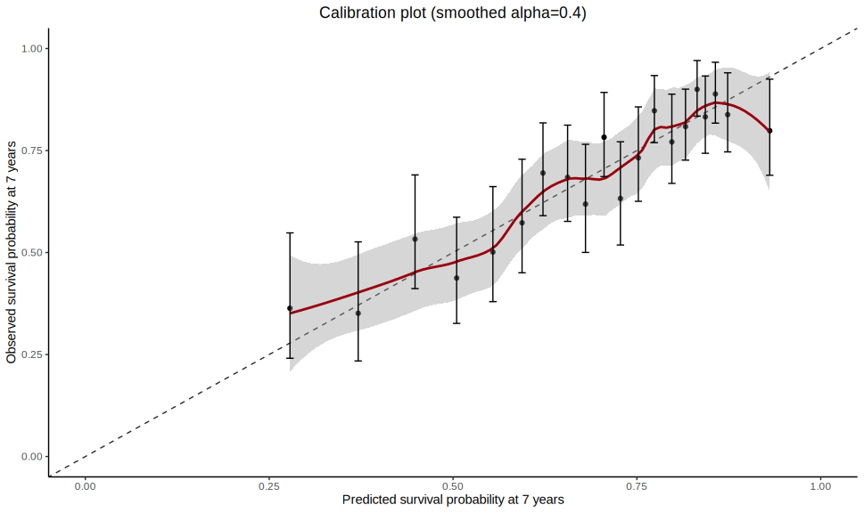

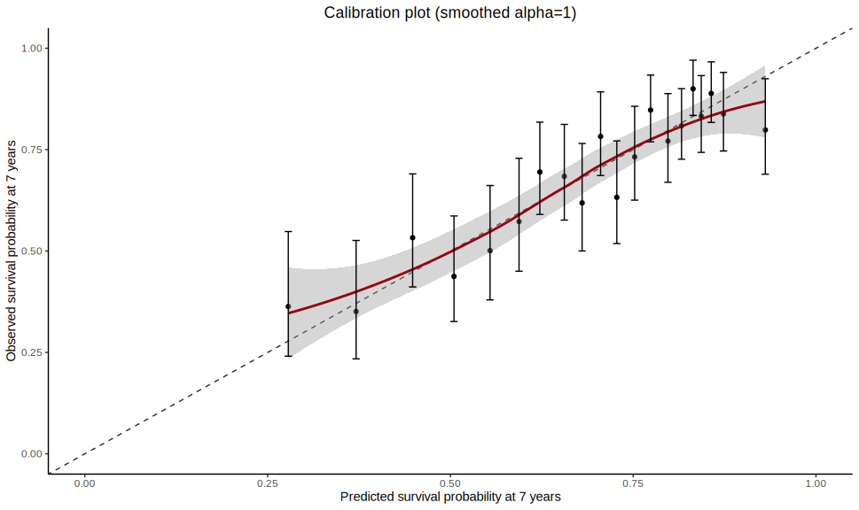

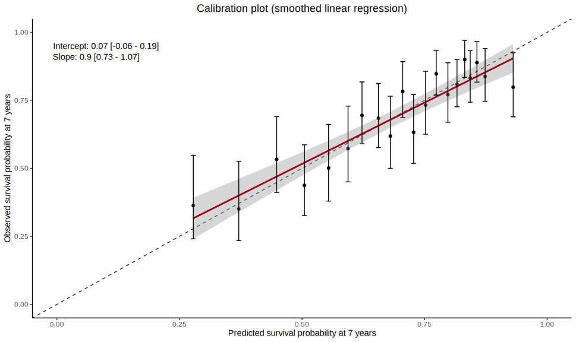

## Discrimination du modèle

### Discrimination du modèle complet

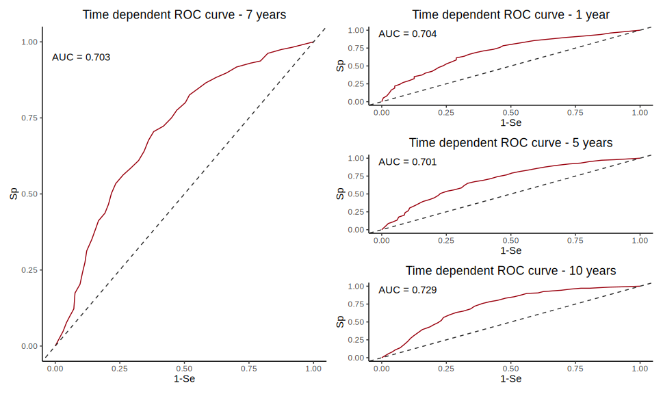

### Discrimination du score

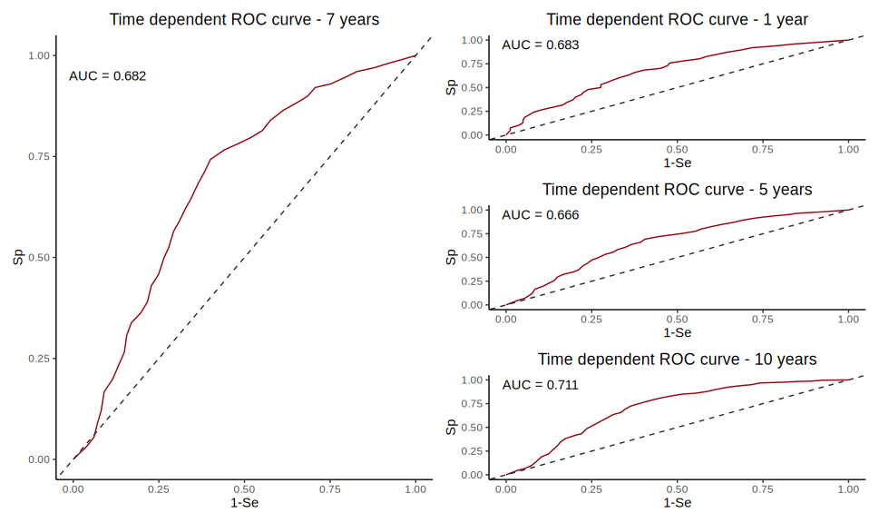

### Discrimination par strates

#### Risque faible vs. élevé

[figure not shown]

#### Risque faible

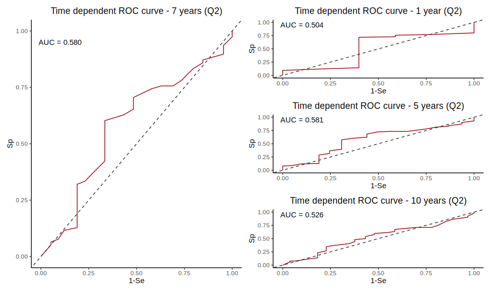

#### Risque élevé

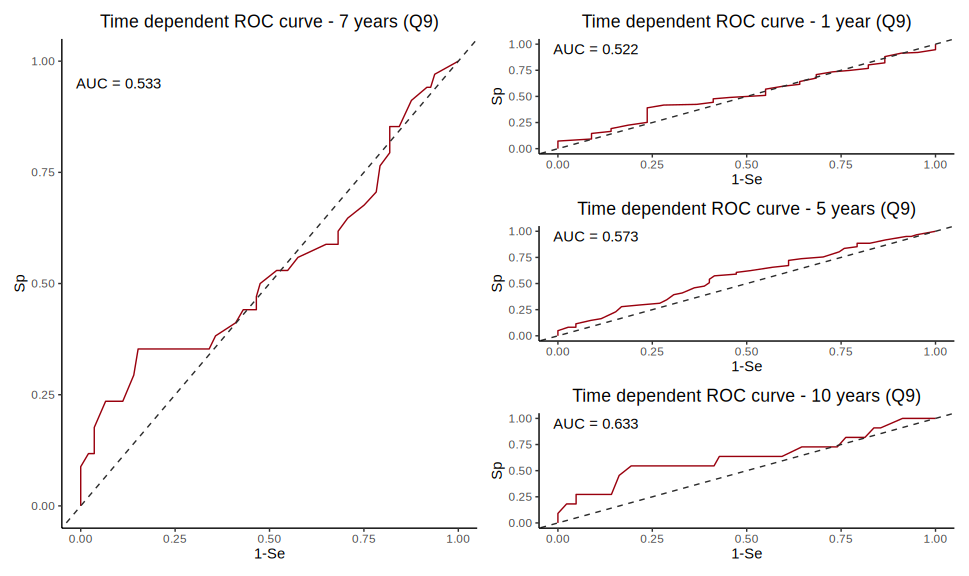